# STAT 140

FALL 2019

## ANNOUNCEMENTS

**Homework** - due Wednesday (10/23) at 3 PM - Ch. 4

**Quiz** - Wednesday (10/23) - Ch. 4 (first five minutes of class)

**R Lab** - sampling distributions and Central Limit Theorem

**Office Hours**

- Monday 10:45-11:45 AM
- Tuesday 9:45-10:45 AM; 2:45-3:45 PM

## POINT ESTIMATES AND SAMPLING VARIABILITY

## COMPARTMENTAL EPIDEMIC MODEL EXAMPLE

```r
## Create a set of 99,500 individuals, where 5% of them get sick
## and 95% do not get sick
pop_size <- 99500
possible_entries <- c(rep("susceptible", 0.95*pop_size),
                      rep("infectious", 0.05*pop_size))

## Sample 1000 entries without replacement
sampled_entries <- sample(possible_entries, size=1000)

## Compute p_hat: count number that become infectious,
## then divide by sample size
sum(sampled_entries=="infectious")/1000
```

```
## [1] 0.042
```

## COMPARTMENTAL EPIDEMIC MODEL EXAMPLE

```r
## Create a set of 99,500 individuals, where 5% of them get sick
## and 95% do not get sick
pop_size <- 99500
possible_entries <- c(rep("susceptible", 0.95*pop_size),
                      rep("infectious", 0.05*pop_size))

## Sample 1000 entries without replacement
sampled_entries <- sample(possible_entries, size=1000)

## Compute p_hat: count number that become infectious,
## then divide by sample size
sum(sampled_entries=="infectious")/1000
```

```
## [1] 0.048
```

## WHAT WE KNOW SO FAR…

- **Point estimate**:
- **Parameter**:
- **Error**:
- **Sample size**:

## WHAT WE KNOW SO FAR…

- **Point estimate**: sample statistic, observed from sample
- **Parameter**: population level quantity we are interested in
- **Error**: difference observed from sample to parameter
- **Sample size**: number of observations from population, denoted \(n\)

## NEW CONCEPTS

- **Sampling error**:
- **Bias**:

## NEW CONCEPTS

- **Sampling error**: how much an estimate will tend to vary from one sample to the next
- **Bias**: systematic tendancy to over- or under-estimate the true population value

## SAMPLING DISTRIBUTIONS

## COMPARTMENTAL EPIDEMIC MODEL EXAMPLE

```r
## store sample proportions from 2000 samples
n <- 2000
cem_df <- data.frame(samp_prop=rep(NA, n))

## (1) Take sample of size 1000
## (2) For each sample, calculate sample proportion
for (i in 1:n){
  sampled_entries <- sample(possible_entries, size=1000)
  cem_df$samp_prop[i] <- sum(sampled_entries=="infectious")/1000
}
```

## COMPARTMENTAL EPIDEMIC MODEL EXAMPLE

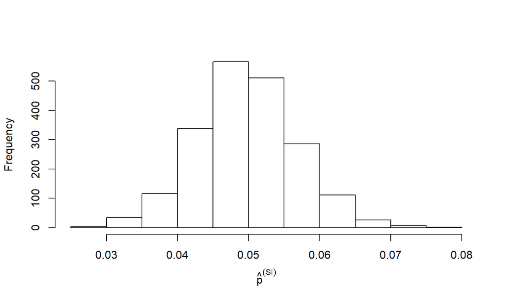

```r
hist(cem_df$samp_prop, main="", xlab=expression(hat(p)^{(SI)}))
```

## SAMPLING DISTRIBUTIONS

A **sampling distribution** is the probability distribution associated with a statistic calculated from a random sample.

## SAMPLING DISTRIBUTIONS

- **Center:**
- **Spread:**
- **Shape:**

## SAMPLING DISTRIBUTIONS

- **Center:** center of the sampling distribution is the same as the parameter we want to estimate
- **Spread:**
- **Shape:**

## SAMPLING DISTRIBUTIONS

- **Center:** center of the sampling distribution is the same as the parameter we want to estimate
- **Spread:** variability of a point estimate, known as *standard error*
- **Shape:**

## SAMPLING DISTRIBUTIONS

- **Center:** center of the sampling distribution is the same as the parameter we want to estimate
- **Spread:** variability of a point estimate, known as *standard error*
- **Shape:** symmetric and bell-shaped, appears normal

## CENTRAL LIMIT THEOREM

## EXAMPLE

```r
## Install faraway package with fruitfly data
# install.packages("faraway")

## Load library
library(faraway)

## Load fruitfly data
data("fruitfly")

## Look at first few entries
head(fruitfly, n=4)
```

```
##   thorax longevity activity
## 1   0.68        37     many
## 2   0.68        49     many
## 3   0.72        46     many
## 4   0.72        63     many
```

## EXAMPLE

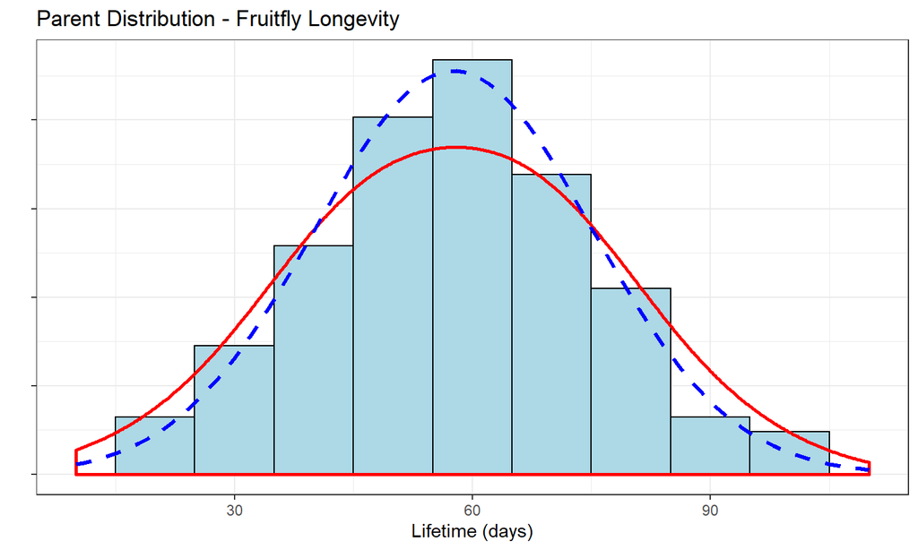

- Solid red line - true density
- Dotted blue line - Normal(\(\mu=\) 57.621, \(\sigma=\) 17.518)

## EXAMPLE

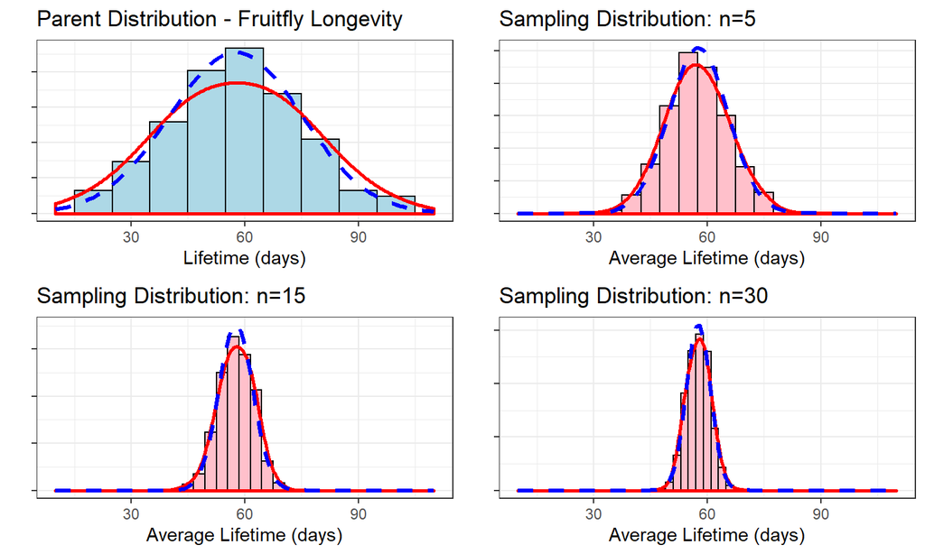

## CENTRAL LIMIT THEOREM - SAMPLE MEAN (normal)

When observations \(X_1,...,X_n\) are *independent* and *drawn from a normal distribution* with mean \(\mu\) and standard deviation \(\sigma\), the sample mean \(\bar{X}\) will tend to follow a normal distribution with mean \(\mu_{\bar{X}}=\mu\) and standard error \(\sigma_{\bar{X}}=\frac{\sigma}{\sqrt{n}}\) .

## EXAMPLE

```r
## Load airquality data
data("airquality")

## Look at first few entries
head(airquality, n=4)
```

```
##   Ozone Solar.R Wind Temp Month Day
## 1    41     190  7.4   67     5   1
## 2    36     118  8.0   72     5   2
## 3    12     149 12.6   74     5   3
## 4    18     313 11.5   62     5   4
```

## EXAMPLE

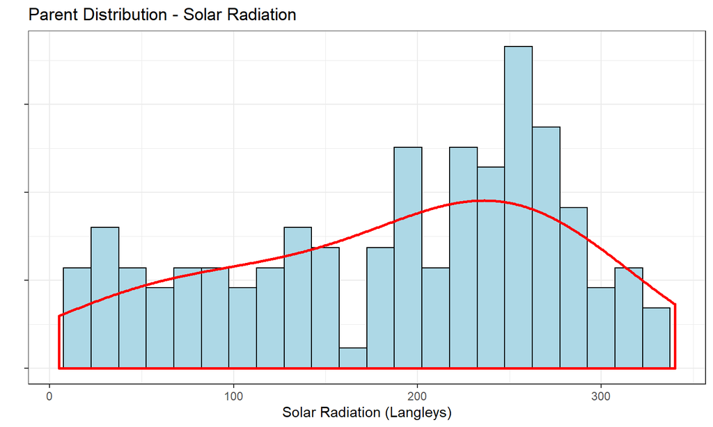

## EXAMPLE

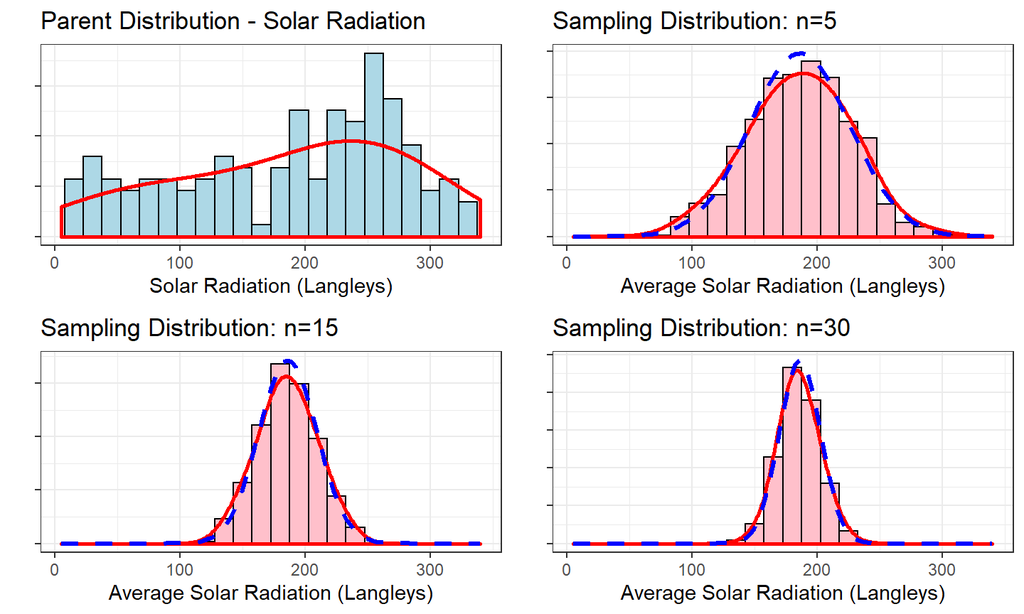

## CENTRAL LIMIT THEOREM - SAMPLE MEAN (general)

When observations \(X_1,...,X_n\) are *independent*, drawn from a distribution with mean \(\mu\) and standard deviation \(\sigma\), and the *sample size is sufficiently large*, the sample mean \(\bar{X}\) will tend to follow a normal distribution with mean \(\mu_{\bar{X}}=\mu\) and standard error \(\sigma_{\bar{X}}=\frac{\sigma}{\sqrt{n}}\) .

The sample size is generally “sufficiently large” when \(n \geq 30\).

## EXAMPLE

According to the latest Democratic Primary poll results, Warren’s probability of winning is 0.237 ([RealClearPolitics](https://www.realclearpolitics.com/epolls/2020/president/us/2020_democratic_presidential_nomination-6730.html))

## EXAMPLE

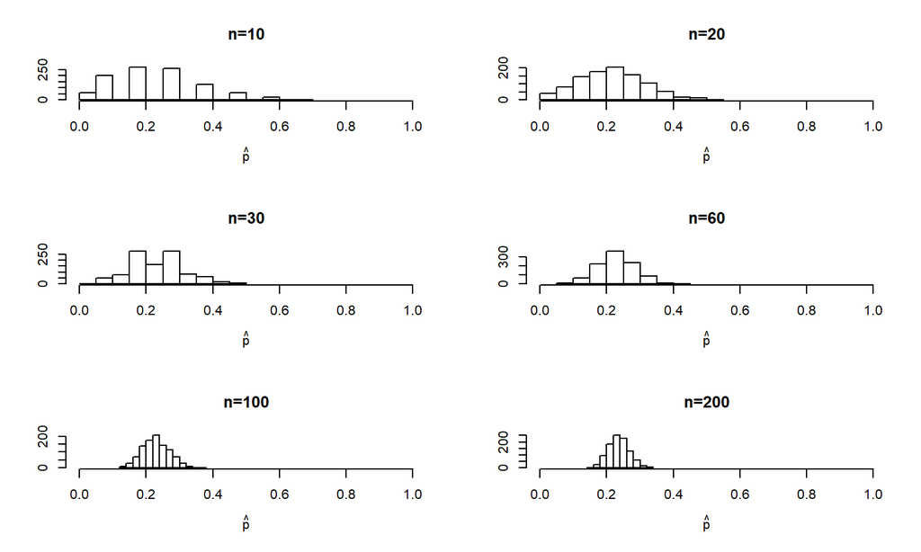

## CENTRAL LIMIT THEOREM - SAMPLE PROPORTION

When observations are *independent* and the *sample size is sufficiently large*, the sample proportion \(\hat{p}\) will tend to follow a normal distribution with mean \(\mu_{\hat{p}}=p\) and standard error \(SE_{\hat{p}}=\sqrt{\frac{p(1-p)}{n}}\).

The sample size is generally “sufficiently large” when two conditions are satisfied:

1. \(np \geq 10\);
2. \(np(1-p) \geq 10\).

## CENTRAL LIMIT THEOREM - SAMPLE PROPORTION

In practice \(p\) is unknown. It tends to be reasonable to plug in \(\hat{p}\):

Standard error:

- \(SE_{\hat{p}}=\sqrt{\frac{\hat{p}(1-\hat{p})}{n}}\)

The sample size is generally “sufficiently large” when two conditions are satisfied:

1. \(n\hat{p} \geq 10\);
2. \(n\hat{p}(1-\hat{p}) \geq 10\).

## INDEPENDENT SAMPLE OBSERVATIONS

1. Subjects in an experiment that were randomly assigned to treatment groups are independent.
2. Observations from a simple random sample are independent.
3. Other cases require your best judgement.

## PRACTICE

If \(X \sim Normal(\mu, \sigma)\), then the sampling distribution for the mean \(\bar{X}\) is

1. approximately \(Normal(\mu, \sigma/\sqrt{n})\) for \(n \geq 30\)
2. exactly \(Normal(\mu, \sigma/\sqrt{n})\)
3. approximately \(Normal(\mu, \sigma)\) for \(n \geq 30\)
4. exactly \(Normal(\mu, \sigma)\)

## PRACTICE

If \(X \sim Normal(\mu, \sigma)\), then the sampling distribution for the mean \(\bar{X}\) is

1. approximately \(Normal(\mu, \sigma/\sqrt{n})\) for \(n \geq 30\)
2. exactly \(Normal(\mu, \sigma/\sqrt{n})\)
3. approximately \(Normal(\mu, \sigma)\) for \(n \geq 30\)
4. exactly \(Normal(\mu, \sigma)\)

## REFERENCES

- Diez et al. (2019) OpenIntro Statistics, Fourth Edition